# Homework - Week 05

```r
library(rethinking)
library(ggplot2)
library(dplyr)
library(tidyr)
library(purrr)
library(dagitty)
library(patchwork)
```

## Problem 01

The data in data(NWOGrants) are outcomes for scientific funding applications for the Netherlands Organization for Scientific Research (NWO) from 2010–2012 (see van der Lee and Ellemers doi:10.1073/pnas.1510159112). These data have a structure similar to the UCBAdmit data discussed in Chapter 11 and in lecture. There are applications and each has an associated gender (of the lead researcher). But instead of departments, there are disciplines. Draw a DAG for this sample. Then use the backdoor criterion and a binomial GLM to estimate the TOTAL causal effect of gender on grant awards.

```r
data(NWOGrants)
df_grants <- NWOGrants %>%
  mutate(gender = if_else(gender == "m", 1, 2),
         discipline_label = discipline,
         discipline = as.numeric(discipline)) # male = 1, female = 2

vct_discipline_mapper <- df_grants %>%
  distinct(discipline, discipline_label) %>%
  arrange(discipline) %>%
  pull(discipline_label) %>% as.character()
df_grants
```

```
   discipline gender applications awards    discipline_label
1           1      1           83     22   Chemical sciences
2           1      2           39     10   Chemical sciences
3           6      1          135     26   Physical sciences
4           6      2           39      9   Physical sciences
5           7      1           67     18             Physics
6           7      2            9      2             Physics
7           3      1          230     33          Humanities
8           3      2          166     32          Humanities
9           9      1          189     30  Technical sciences
10          9      2           62     13  Technical sciences
11          4      1          105     12   Interdisciplinary
12          4      2           78     17   Interdisciplinary
13          2      1          156     38 Earth/life sciences
14          2      2          126     18 Earth/life sciences
15          8      1          425     65     Social sciences
16          8      2          409     47     Social sciences
17          5      1          245     46    Medical sciences
18          5      2          260     29    Medical sciences
```

### Notation

`discipline` -> D `gender` -> G `applications` -> A `awards` -> W

The following DAG shows the relationships between the gender, discipline and awards variables.

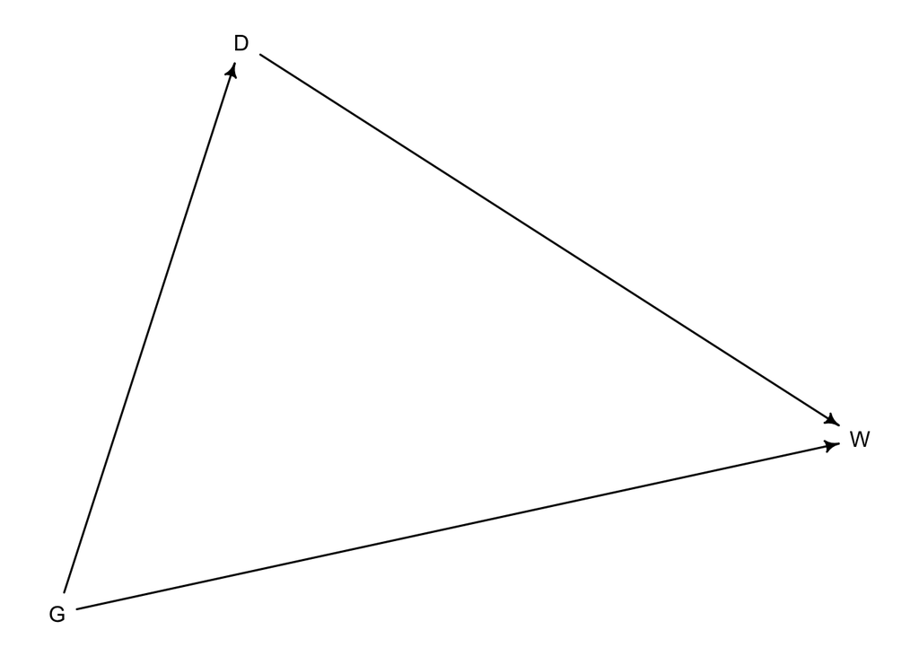

```r
dag_grants <- dagitty(
  "dag {
  G -> D
  G -> W
  D -> W
  }"
)

drawdag(dag_grants)
```

Using the backdoor criterion in order to estimate the **total** causal effect of gender on grant awards means to use and empty adjustment set.

```r
dagitty::adjustmentSets(
  dag_grants, exposure = "G", outcome = "W", effect = "total"
  )
```

```
 {}
```

```r
m1.1 <- ulam(
  flist = alist(
    awards ~ dbinom(applications, p),
    logit(p) <- a[gender],
    a[gender] ~ dnorm(0, 1.5)
  ),
  data = df_grants, chains = 4
)
```

[output not shown]

```r
precis(m1.1, depth = 2)
```

```
          mean         sd      5.5%     94.5%    n_eff     Rhat4
a[1] -1.534372 0.06266991 -1.633585 -1.432587 1359.934 1.0005569
a[2] -1.741938 0.08141484 -1.871264 -1.614049 1422.739 0.9987166
```

```r
set.seed(23423)
prior <- extract.prior(m1.1)
```

[output not shown]

```r
posterior <- extract.samples(m1.1)
```

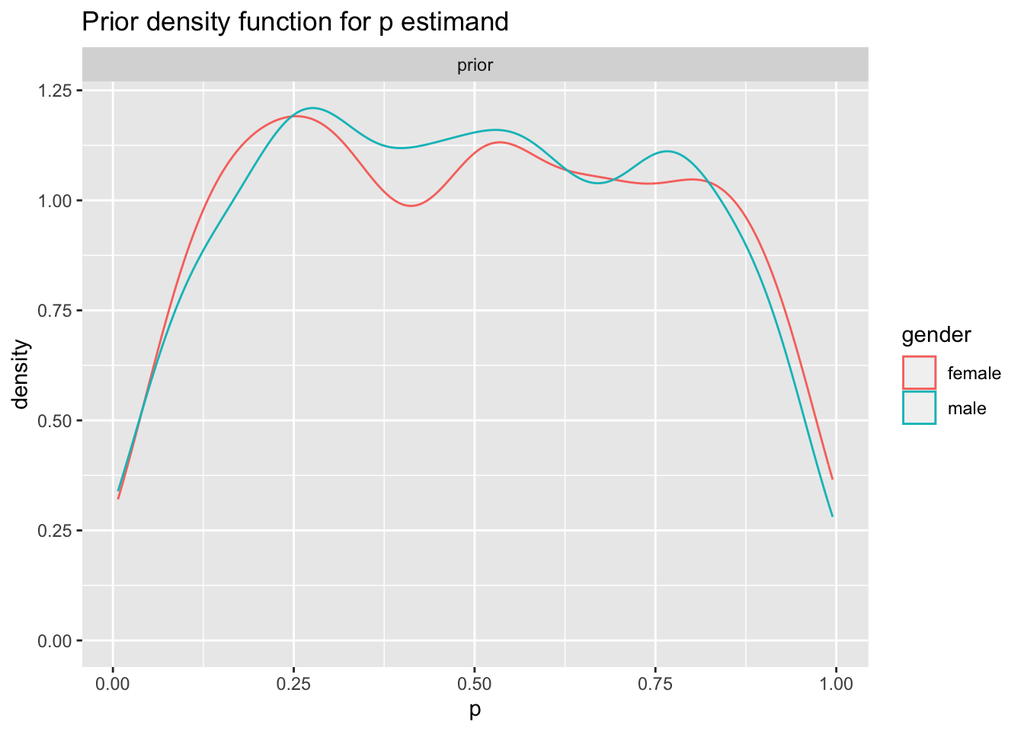

```r
df_prior <- inv_logit(prior$a) %>%
  as.data.frame() %>%
  setNames(c("male", "female")) %>% gather(key = "gender", value = "p") %>%
  mutate(source="prior")

ggplot(data = df_prior) +
  geom_density(aes(x=p, color=gender)) +
  facet_grid(. ~ source) +
  labs(title = "Prior density function for p estimand")
```

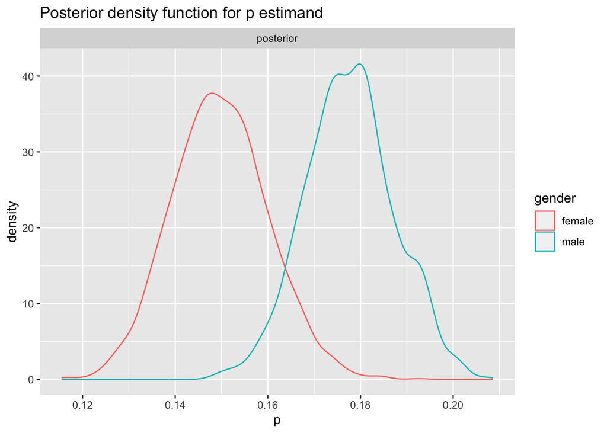

```r
df_posterior <- inv_logit(posterior$a) %>% as.data.frame() %>% setNames(c("male", "female"))

to_plot <- df_posterior %>% gather(key = "gender", value = "p") %>%
  mutate(source="posterior")

ggplot(data = to_plot) +
  geom_density(aes(x=p, color=gender)) +
  facet_grid(. ~ source) +
  labs(title = "Posterior density function for p estimand")
```

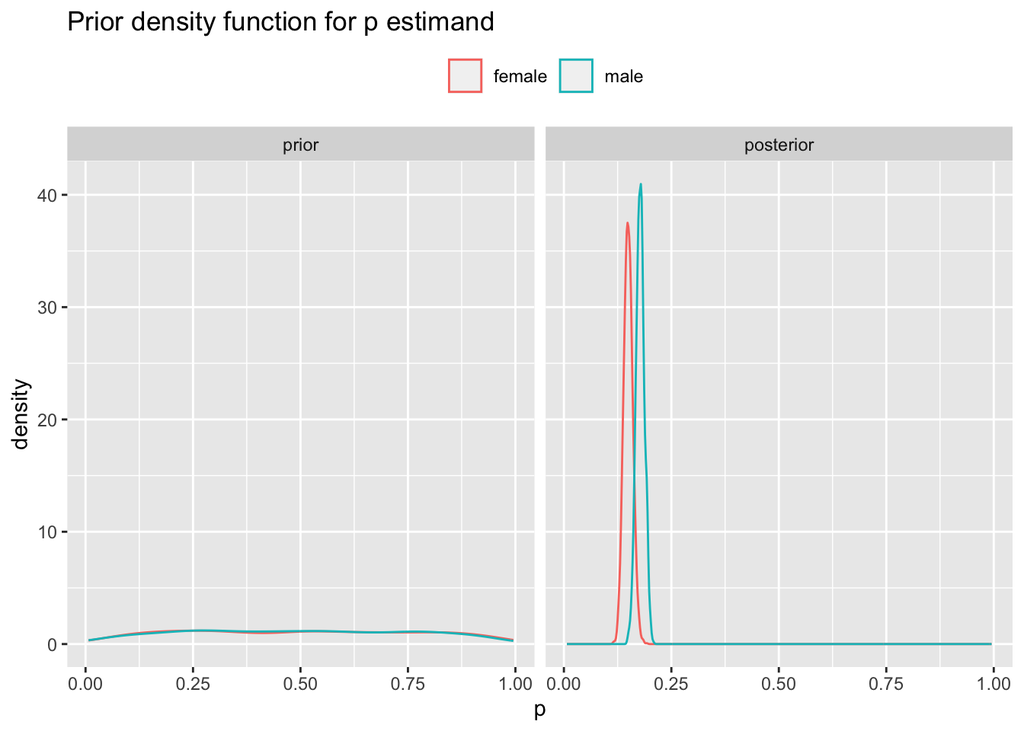

```r
df_prior <- inv_logit(prior$a) %>%
  as.data.frame() %>%
  setNames(c("male", "female")) %>%
  mutate(source="prior")

df_posterior <- inv_logit(posterior$a) %>%
  as.data.frame() %>%
  setNames(c("male", "female")) %>%
  mutate(source="posterior")

to_plot <- bind_rows(df_prior, df_posterior) %>% gather(key = "gender", value = "p", -source) %>% mutate(source = factor(source, levels=unique(source)))

ggplot(data = to_plot) +
  geom_density(aes(x=p, color=gender)) +
  facet_grid(. ~ source, scales = "free_y") +
  labs(title = "Prior density function for p estimand") +
  theme(legend.position = "top",
        legend.title = element_blank())
```

```r
df_total_contrast <- df_posterior %>%
  mutate(contrast = male - female)
precis(df_total_contrast)
```

```
              mean          sd        5.5%      94.5%     histogram
male     0.1776701 0.009622524 0.162737387 0.19349275 ▁▁▁▂▅▇▇▇▃▂▁▁▁
female   0.1496595 0.010331887 0.133752934 0.16636798     ▁▁▃▇▇▂▁▁▁
source         NaN          NA          NA         NA
contrast 0.0280106 0.013966944 0.005402537 0.05022525     ▁▁▂▅▇▇▃▁▁
```

The contrast between the male and female estimates shows a difference between 1pp and 5pp favoring man for grant awards within a 89% interval.

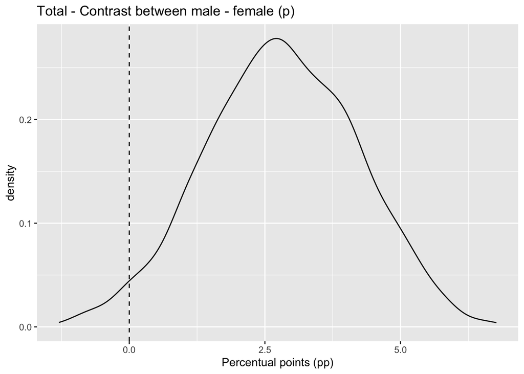

```r
plot_total_contrast <- ggplot(data=df_total_contrast) +
  geom_density(aes(x=contrast * 100)) +
  geom_vline(aes(xintercept=0), linetype = 2) +
  labs(x = "Percentual points (pp)",
       title = "Total - Contrast between male - female (p)")
plot_total_contrast
```

### Posterior validation check

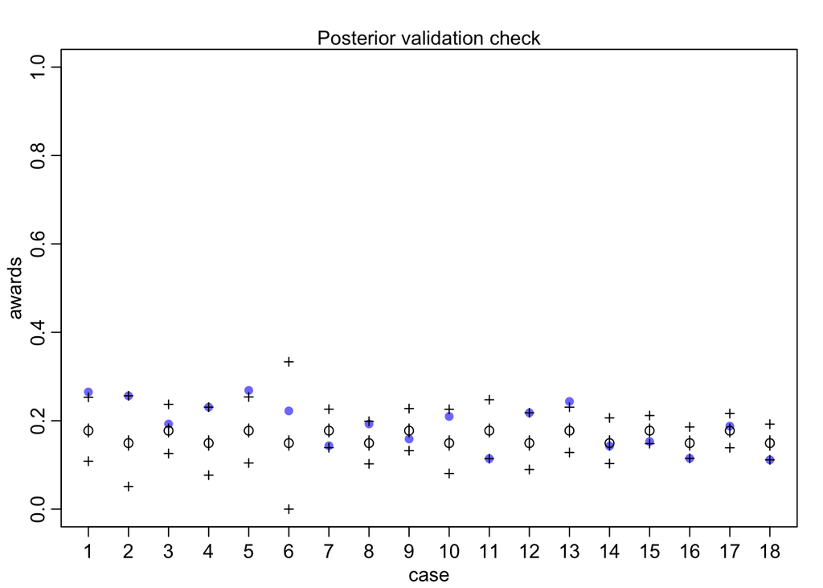

```r
postcheck(m1.1)
```

## Problem 02

Now estimate the DIRECT causal effect of gender on grant awards. Use the same DAG as above to justify one or more binomial models. Compute the average direct causal effect of gender, weighting each discipline in proportion to the number of applications in the sample. Refer to the marginal effect example in Lecture 9 for help.

### Model `gender` + `discipline`

```r
m2.1 <- ulam(
  flist = alist(
    awards ~ dbinom(applications, p),
    logit(p) <- a[gender] + beta[discipline],
    a[gender] ~ dnorm(0, 1.5),
    beta[discipline] ~ dnorm(0, 1.5)
  ),
  data = df_grants, chains = 4
)
```

[output not shown]

```r
precis(m2.1, depth = 2)
```

```
              mean        sd       5.5%      94.5%    n_eff    Rhat4
a[1]    -1.1519229 0.4797649 -1.8949399 -0.3859587 166.1751 1.016323
a[2]    -1.2907392 0.4863983 -2.0524045 -0.5174544 168.5036 1.017182
beta[1]  0.1528759 0.5195753 -0.6687818  0.9873516 192.4180 1.014898
beta[2] -0.1890742 0.4967199 -0.9820489  0.5832404 173.0324 1.015072
beta[3] -0.4215816 0.4931504 -1.2020750  0.3406870 178.8491 1.015370
beta[4] -0.4642066 0.5121205 -1.2684080  0.3546467 190.5179 1.013413
beta[5] -0.5280398 0.4942061 -1.3053032  0.2563873 170.0942 1.017126
beta[6] -0.2062108 0.5026541 -1.0194032  0.5757386 185.5512 1.015686
beta[7]  0.1171387 0.5357244 -0.7327300  0.9560886 197.0516 1.010986
beta[8] -0.6475505 0.4879047 -1.4213237  0.1117571 172.0920 1.016121
beta[9] -0.3940086 0.5002207 -1.2058491  0.3704511 179.1944 1.016182
```

```r
set.seed(93887)
m2.1_prior <- extract.prior(m2.1)
```

[output not shown]

```r
m2.1_posterior <- extract.samples(m2.1)
```

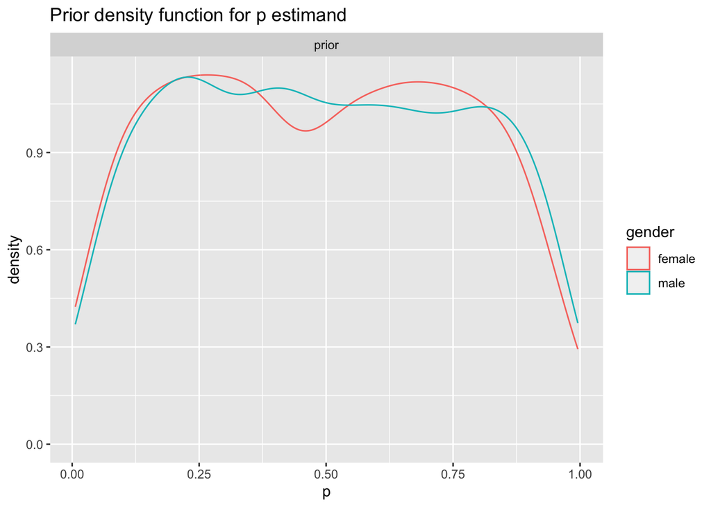

```r
df_m2.1_prior <- inv_logit(m2.1_prior$a) %>% as.data.frame() %>% setNames(c("male", "female")) %>% gather(key = "gender", value = "p") %>%
  mutate(source="prior")

ggplot(data = df_m2.1_prior) +
  geom_density(aes(x=p, color=gender)) +
  facet_grid(. ~ source) +
  labs(title = "Prior density function for p estimand")
```

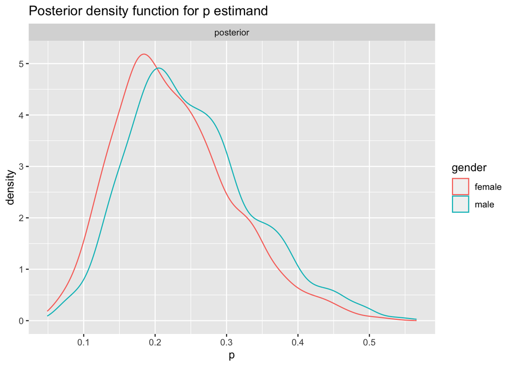

```r
df_m2.1_posterior <- inv_logit(m2.1_posterior$a) %>% as.data.frame() %>% setNames(c("male", "female"))

to_plot <- df_m2.1_posterior %>% gather(key = "gender", value = "p") %>%
  mutate(source="posterior")

ggplot(data = to_plot) +
  geom_density(aes(x=p, color=gender)) +
  facet_grid(. ~ source) +
  labs(title = "Posterior density function for p estimand")
```

```r
df_m2.1_total_contrast <- df_m2.1_posterior %>%
  mutate(contrast = male - female)
precis(df_m2.1_total_contrast)
```

```
               mean         sd         5.5%      94.5%   histogram
male     0.25037025 0.08707326  0.130682260 0.40469055 ▁▂▇▇▇▃▂▁▁▁▁
female   0.22646230 0.08242872  0.113809653 0.37344769 ▁▁▃▇▇▅▃▁▁▁▁
contrast 0.02390796 0.01881473 -0.003727001 0.05610646   ▁▁▂▇▇▃▁▁▁
```

The contrast between the male and female estimands shows a difference between 0pp and 6pp favoring man for grant awards within a 89% interval.

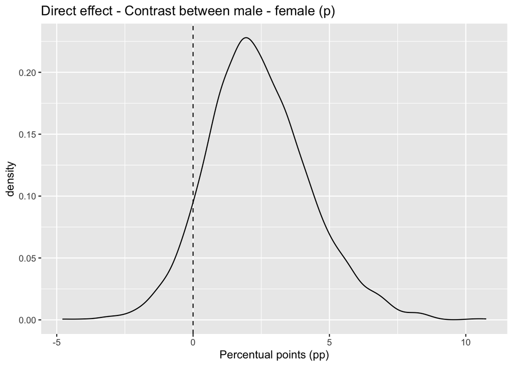

```r
ggplot(data=df_m2.1_total_contrast) +
  geom_density(aes(x=contrast * 100)) +
  geom_vline(aes(xintercept=0), linetype = 2) +
  labs(x = "Percentual points (pp)",
       title = "Direct effect - Contrast between male - female (p)")
```

#### Posterior validation check

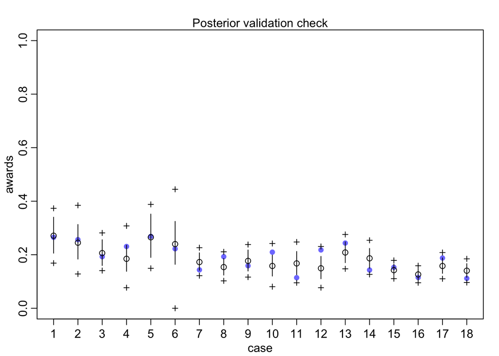

```r
postcheck(m2.1)
```

### Model `gender` with `discipline` (marginal effects)

```r
m2.2 <- ulam(
  flist = alist(
    awards ~ dbinom(applications, p),
    logit(p) <- a[gender, discipline],
    matrix[gender, discipline]:a ~ dnorm(0, 1.5)
  ),
  data = df_grants, chains = 4
)
```

[output not shown]

```r
precis(m2.2, depth = 3)
```

```
             mean        sd      5.5%        94.5%    n_eff     Rhat4
a[1,1] -1.0037991 0.2503568 -1.411501 -0.606368590 2422.522 0.9994339
a[1,2] -1.1176615 0.1774208 -1.409508 -0.843781365 2355.332 0.9991765
a[1,3] -1.7626154 0.1829137 -2.065223 -1.483375800 2631.751 0.9987813
a[1,4] -2.0078902 0.2934741 -2.482854 -1.560029600 2414.345 0.9985429
a[1,5] -1.4519892 0.1596648 -1.703631 -1.191374050 2913.106 0.9987195
a[1,6] -1.4074725 0.2108790 -1.761166 -1.080663400 2213.764 0.9997346
a[1,7] -0.9887466 0.2647223 -1.425503 -0.578574080 2499.893 0.9992363
a[1,8] -1.7034578 0.1359186 -1.930461 -1.489416450 2028.736 1.0004234
a[1,9] -1.6477525 0.1958563 -1.957549 -1.340551650 2662.162 0.9994960
a[2,1] -1.0426632 0.3594856 -1.653579 -0.476120685 2648.952 0.9985593
a[2,2] -1.7634639 0.2512877 -2.171185 -1.387126250 2497.372 0.9988829
a[2,3] -1.4190961 0.1991261 -1.738257 -1.109423950 3057.447 0.9992333
a[2,4] -1.2583620 0.2633359 -1.670196 -0.849011915 2784.316 0.9990343
a[2,5] -2.0531707 0.1986059 -2.379624 -1.757430400 2818.760 0.9989748
a[2,6] -1.1566877 0.3623632 -1.737558 -0.596196310 2283.288 1.0003902
a[2,7] -1.0792765 0.7077294 -2.242673  0.009810643 2451.710 0.9984299
a[2,8] -2.0327390 0.1502772 -2.278125 -1.799800200 2385.467 1.0001989
a[2,9] -1.2977558 0.3150427 -1.814353 -0.798322120 3241.555 0.9989608
```

```r
set.seed(2385012)
m2.2_prior <- extract.prior(m2.2)
```

[output not shown]

```r
m2.2_posterior <- extract.samples(m2.2)
```

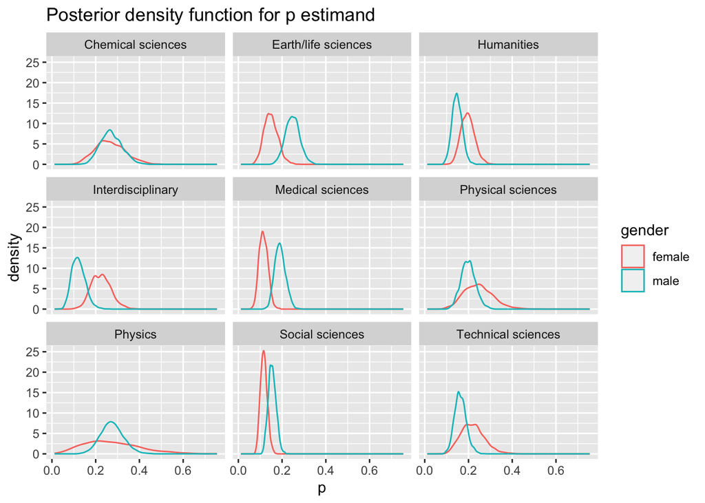

```r
# Manage 3d matrix
col_names <- c( "gender", "discipline")
df_m2.2_posterior <- map(.x=dim(m2.2_posterior$a)[-1], function(x) 1:x) %>%
  setNames(col_names) %>% expand_grid(!!!.) %>%
  as_tibble() %>%
  mutate(a = map2(gender, discipline, function(x,y) m2.2_posterior$a[, x, y])) %>%
  unnest(cols = a) %>%
  mutate(p = inv_logit(a),
         source = "posterior",
         gender = if_else(gender == 1, "male", "female"),
         discipline = map_chr(discipline, .f=~vct_discipline_mapper[.x]))

ggplot(data = df_m2.2_posterior) +
  geom_density(aes(x=p, color=gender, group=gender)) +
  facet_wrap(. ~ discipline) +
  labs(title = "Posterior density function for p estimand")
```

```r
df_m2.2_total_contrast <- df_m2.2_posterior %>%
  select(-a, -source) %>%
  group_by(gender, discipline) %>%
  mutate(sample=row_number()) %>%
  ungroup() %>%
  spread(key = gender, value=p) %>%
  mutate(contrast = male - female)
```

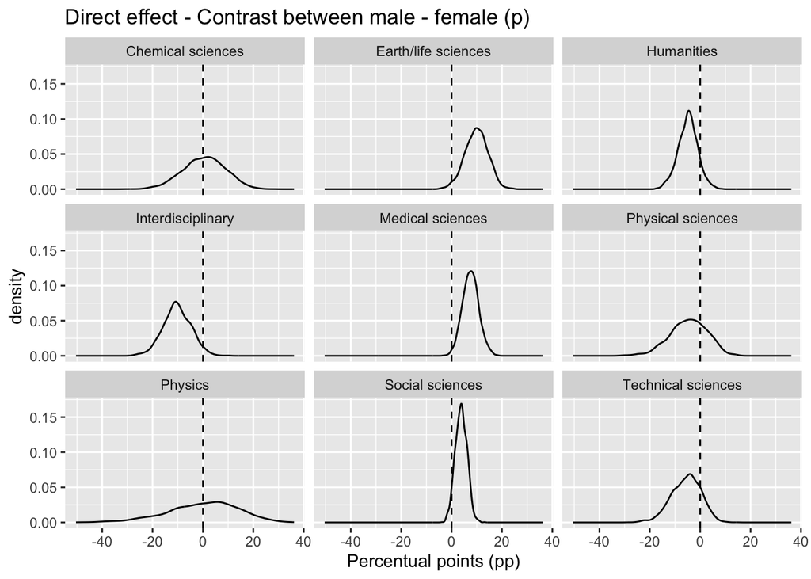

```r
ggplot(data=df_m2.2_total_contrast) +
  geom_density(aes(x=contrast * 100)) +
  geom_vline(aes(xintercept=0), linetype = 2) +
  facet_wrap(. ~ discipline) +
  labs(x = "Percentual points (pp)",
       title = "Direct effect - Contrast between male - female (p)")
```

#### Marginal effect over disciplines

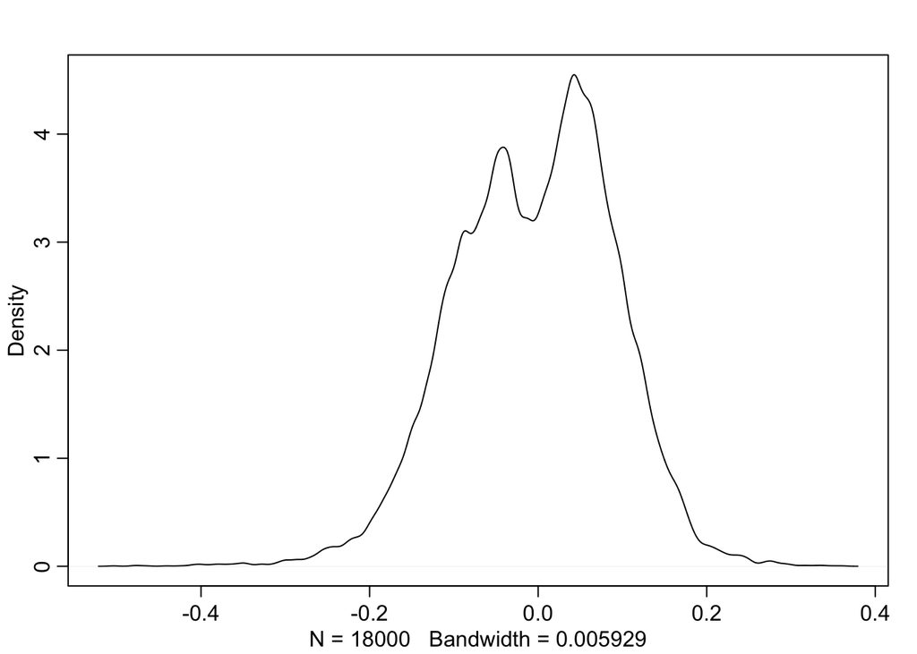

```r
df_applications_per_discipline <- df_grants %>%
  group_by(discipline) %>%
  summarise(applications = sum(applications), .groups = "drop")

# Simulate all applications were men
p_male <- link(
  m2.2,
  data=df_applications_per_discipline %>% mutate(gender=1) %>% as.list
  )
# Simulate all applications were women
p_female <- link(
  m2.2,
  data=df_applications_per_discipline %>% mutate(gender=2) %>% as.list
  )

dens(p_male - p_female)
```

#### Post stratification

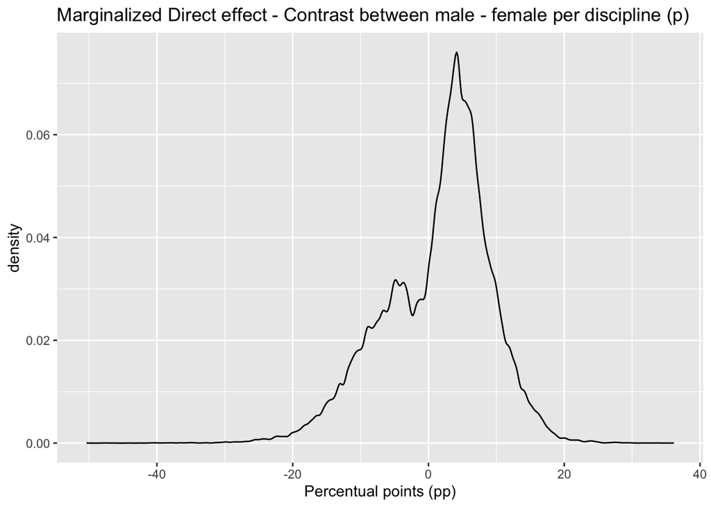

```r
# number of applicatons to simulate
total_apps <- df_grants %>% pull(applications) %>% sum

# number of applications per department
apps_per_dept <- sapply( 1:9 , function(i)
sum(df_grants$applications[df_grants$discipline==i]) )
# simulate as if all apps from men
p_male <- link(m2.2,data=list(
 discipline=rep(1:9,times=apps_per_dept),
 applications=rep(1,total_apps),
 gender=rep(1,total_apps)))
# simulate as if all apps from woman
p_female <- link(m2.2,data=list(
 discipline=rep(1:9,times=apps_per_dept),
 applications=rep(1,total_apps),
 gender=rep(2,total_apps)))
# summarize
marginalized_contrast = p_male - p_female

plot_marginalized_contrast <- ggplot() +
  geom_density(aes(x=as.vector(marginalized_contrast) * 100)) +
  labs(x = "Percentual points (pp)",
       title = "Marginalized Direct effect - Contrast between male - female per discipline (p)")

plot_marginalized_contrast
```

```r
precis(tibble(marginalized_contrast = as.vector(marginalized_contrast)))
```

```
                            mean         sd       5.5%     94.5%  histogram
marginalized_contrast 0.01352575 0.07821925 -0.1237636 0.1212557 ▁▁▁▁▁▃▇▁▁▁
```

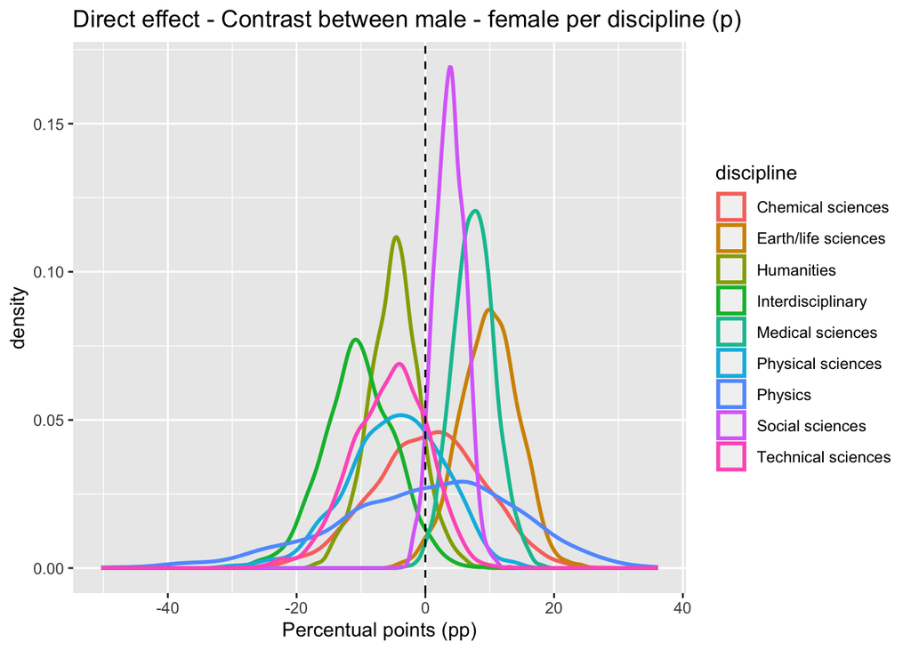

```r
plot_direct_effect_per_discipline <- ggplot(data=df_m2.2_total_contrast) +
  geom_density(aes(x=contrast * 100, color = discipline), linewidth=1) +
  geom_vline(aes(xintercept=0), linetype = 2) +
  labs(x = "Percentual points (pp)",
       title = "Direct effect - Contrast between male - female per discipline (p)")
plot_direct_effect_per_discipline
```

#### Posterior validation check

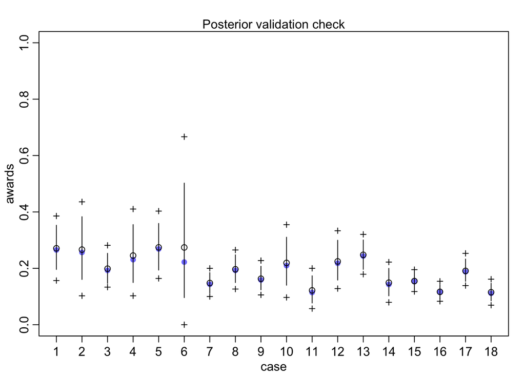

```r
postcheck(m2.2)
```

## Problem 03

Considering the total effect (problem 1) and direct effect (problem 2) of gender, what causes contribute to the average difference between women and men in **award rate** in this sample? It is not necessary to say whether or not there is evidence of discrimination or the presence or absence of unobserved confounds (which are likely!). Simply explain how the direct effects you have estimated make sense (or not) of the total effect.

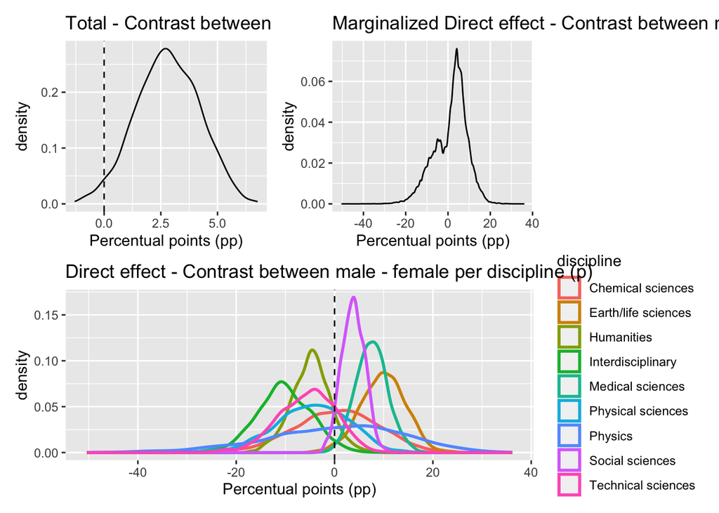

```r
(plot_total_contrast | plot_marginalized_contrast) / plot_direct_effect_per_discipline
```

The total effect plot (top-left) shows that men seem to be advantages for grant awards. Likewise, looking at the marginalized direct effect (top-right), it is possible to see that a great area of the contrast provides advantages to men. When looking the direct effect’s contrast at discipline level, it is possible to see that some areas like Social Science, Medical Science and Earth and Life Science tend to favor men compared to woman. On the other hand, some of these effect is balanced by other disciplines in which women is favored (e.g. Humanities, Technical Science or Interdisciplinary research).